# PPOL670 | Introduction to Data Science | Week 11

## Support Vector Machine

Let’s explore three versions of the support vector algorithm: linear boundary, a polynomial (kernel) boundary, and a radial boundary. Like the Logistic regression, SVM will complain when there isn’t sufficient variation within a variable.

### Linear Boundary

```r
mod_svm_linear <-
  train(coverage ~ . ,
        data=train_data2, # Training data
        method = "svmLinear", # SVM with a polynomial Kernel
        metric = "ROC", # area under the curve
        tuneGrid = expand.grid(C = c(.5,1)), # Add two tuning parameters
        trControl = control_conditions
  )
```

```r
mod_svm_linear
```

```
Support Vector Machines with Linear Kernel

4002 samples
  11 predictor
   2 classes: 'Coverage', 'No_Coverage'

No pre-processing
Resampling: Cross-Validated (10 fold)
Summary of sample sizes: 800, 801, 800, 801, 800
Resampling results across tuning parameters:

  C    ROC        Sens       Spec
  0.5  0.7774877  0.6969392  0.7113350
  1.0  0.7767458  0.6887603  0.7193955

ROC was used to select the optimal model using the largest value.
The final value used for the model was C = 0.5.
```

### Polynomial Boundary

```r
mod_svm_poly <-
  train(coverage ~ .,
        data=train_data2, # Training data
        method = "svmPoly", # SVM with a polynomial Kernel
        metric = "ROC", # area under the curve
        trControl = control_conditions
  )
```

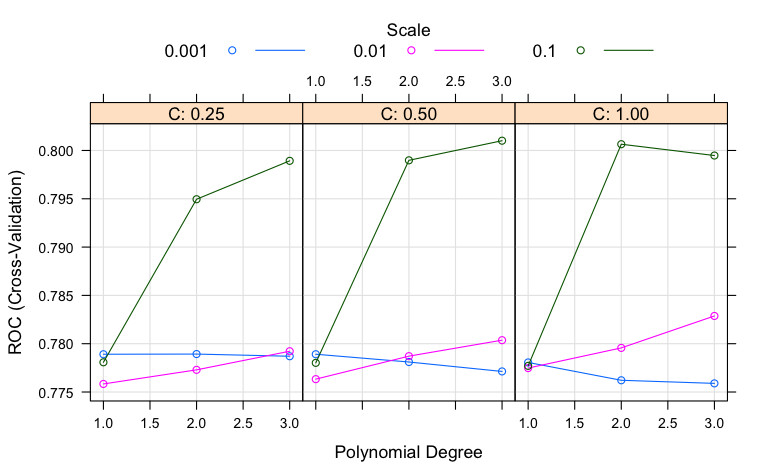

```r
plot(mod_svm_poly)
```

### Radial Boundary

```r
mod_svm_radial <-
  train(coverage ~ .,
        data=train_data2, # Training data
         method = "svmRadial", # SVM with a Radial Kernel
        metric = "ROC", # area under the curve
        trControl = control_conditions
  )
```

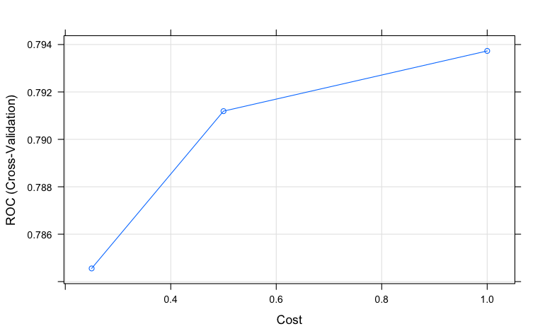

```r
plot(mod_svm_radial)
```

# Model Comparison

How did the different methods perform? Which one did the best?

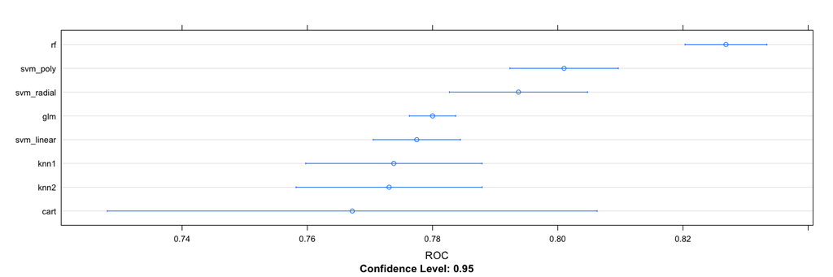

```r
# Organize all model imputs as a list.
mod_list <-
  list(
    glm=mod_logit,
    knn1 = mod_knn,
    knn2 = mod_knn2,
    cart = mod_cart,
    rf = mod_rf,
    svm_linear = mod_svm_linear,
    svm_poly = mod_svm_poly,
    svm_radial = mod_svm_radial
  )

# Generate Plot to compare output.
dotplot(resamples(mod_list),metric = "ROC")
```

# Predictive Performance

Examine the predictive performance of the best performing model.

```r
pred <- predict(mod_rf, newdata = test_data2)
confusionMatrix(table(pred,test_data2$coverage))
```

```
Confusion Matrix and Statistics


pred          Coverage No_Coverage
  Coverage         341          90
  No_Coverage      162         405

               Accuracy : 0.7475
                 95% CI : (0.7193, 0.7742)
    No Information Rate : 0.504
    P-Value [Acc > NIR] : < 2.2e-16

                  Kappa : 0.4955

 Mcnemar's Test P-Value : 7.728e-06

            Sensitivity : 0.6779
            Specificity : 0.8182
         Pos Pred Value : 0.7912
         Neg Pred Value : 0.7143
             Prevalence : 0.5040
         Detection Rate : 0.3417
   Detection Prevalence : 0.4319
      Balanced Accuracy : 0.7481

       'Positive' Class : Coverage
```

We can also use the `yardstick` package to generate specific performance metrics.

```r
# Generates predicted probabilities for both 1 ("Coverage") and 0 ("No Coverage")
pred_probability <- predict(mod_rf,newdata = test_data2,type="prob")
pred <- predict(mod_rf,newdata = test_data2,type="raw")

# Organize as a data frame
preformance <- tibble(truth = test_data2$coverage,
                      prob = pred_probability$Coverage,
                      pred = pred)

# Calculate performance metrics
bind_rows(
  preformance %>% roc_auc(truth,prob),
  preformance %>% accuracy(truth,pred)
)
```

| .metric | .estimator | .estimate |
| --- | --- | --- |
| roc_auc | binary | 0.8304356 |
| accuracy | binary | 0.7474950 |